# Project: Investigate The Movie Database1 (TMDB)

## Introduction

Overview about the data that I'm going analysis This data set contains information about 10,000 movies collected from The Movie Database (TMDb), including user ratings and revenue through this analysis I'm going answer 3 question 1 *Is the high rating movies had certain condition? 2* How revenue of film industry developed over years? and which year had the most production movies? 3_ Which movie had the highest population and revenue?

## Data Wrangling

Firstly I'm going import libraries and exploring the data

### General Properties

```python
# I'm going to import the libreries.
import pandas as pd
import numpy as np
import matplotlib.pyplot as plt
import seaborn as sns
%matplotlib inline
df = pd.read_csv('movies.csv')
```

```python
#Here I'm going to descover the data
df.head(2)
```

|  | id | imdb_id | popularity | budget | revenue | original_title | cast | homepage | director | tagline | ... | overview | runtime | genres | production_companies | release_date | vote_count | vote_average | release_year | budget_adj | revenue_adj |
| --- | --- | --- | --- | --- | --- | --- | --- | --- | --- | --- | --- | --- | --- | --- | --- | --- | --- | --- | --- | --- | --- |
| 0 | 135397 | tt0369610 | 32.985763 | 150000000 | 1513528810 | Jurassic World | Chris Pratt\|Bryce Dallas Howard\|Irrfan Khan\|Vi... | http://www.jurassicworld.com/ | Colin Trevorrow | The park is open. | ... | Twenty-two years after the events of Jurassic ... | 124 | Action\|Adventure\|Science Fiction\|Thriller | Universal Studios\|Amblin Entertainment\|Legenda... | 6/9/2015 | 5562 | 6.5 | 2015 | 137999939.3 | 1.392446e+09 |
| 1 | 76341 | tt1392190 | 28.419936 | 150000000 | 378436354 | Mad Max: Fury Road | Tom Hardy\|Charlize Theron\|Hugh Keays-Byrne\|Nic... | http://www.madmaxmovie.com/ | George Miller | What a Lovely Day. | ... | An apocalyptic story set in the furthest reach... | 120 | Action\|Adventure\|Science Fiction\|Thriller | Village Roadshow Pictures\|Kennedy Miller Produ... | 5/13/2015 | 6185 | 7.1 | 2015 | 137999939.3 | 3.481613e+08 |

2 rows × 21 columns

I'm going to use info() to give me overview about the whole data and if it has mising value

```python
df.info()
```

```
<class 'pandas.core.frame.DataFrame'>
RangeIndex: 10866 entries, 0 to 10865
Data columns (total 21 columns):
id                      10866 non-null int64
imdb_id                 10856 non-null object
popularity              10866 non-null float64
budget                  10866 non-null int64
revenue                 10866 non-null int64
original_title          10866 non-null object
cast                    10790 non-null object
homepage                2936 non-null object
director                10822 non-null object
tagline                 8042 non-null object
keywords                9373 non-null object
overview                10862 non-null object
runtime                 10866 non-null int64
genres                  10843 non-null object
production_companies    9836 non-null object
release_date            10866 non-null object
vote_count              10866 non-null int64
vote_average            10866 non-null float64
release_year            10866 non-null int64
budget_adj              10866 non-null float64
revenue_adj             10866 non-null float64
dtypes: float64(4), int64(6), object(11)
memory usage: 1.7+ MB
```

and now i'm going to use shape to give me the rows and columns number

```python
df.shape
```

```
(10866, 21)
```

### Data Cleaning (Now I'm going delete null values and duplicated rows)

here i'm going to use drop () to delete the columns that i don't need and that make my work easies when i deal with just certain columns

```python
#now I'm going to clean my data
#and here I'm going to drop unnecessary columns that I don't in this analysis
df_1= df.drop(['imdb_id','cast','homepage','tagline','keywords','overview','release_date','production_companies','genres'],axis=1)
```

```python
#see the new data and if has null value
df_1.info()
```

```
<class 'pandas.core.frame.DataFrame'>
RangeIndex: 10866 entries, 0 to 10865
Data columns (total 12 columns):
id                10866 non-null int64
popularity        10866 non-null float64
budget            10866 non-null int64
revenue           10866 non-null int64
original_title    10866 non-null object
director          10822 non-null object
runtime           10866 non-null int64
vote_count        10866 non-null int64
vote_average      10866 non-null float64
release_year      10866 non-null int64
budget_adj        10866 non-null float64
revenue_adj       10866 non-null float64
dtypes: float64(4), int64(6), object(2)
memory usage: 1018.8+ KB
```

and now after see overview about data after droping i'm going see if there any duplicate rows and i'm going to use sum to know the number of duplicate then i'll drop it by using drop duplicated() and make inplace true to make the changes work in data,,

```python
#get the number of duplicate value
sum(df_1.duplicated())
```

```
1
```

```python
#drop the duplicate value
df_1.drop_duplicates(inplace=True)
```

and here i'm going to see the number of null value in director column by using sum then i'll drpo them by dropna()

```python
#get the number of null value in director column
sum(df_1['director'].isnull())
```

```
44
```

```python
#make copy of data after drop null value
df_2=df_1.dropna()
```

and now i'm gonaa check if there still any null value and the number of them by using df_2.isna().sum()

```python
# make sure there is no null value
df_2.isna().sum()
```

[output not shown]

and now i know there are zeros in budget and revenue columns and that will afect in my analsis so i decide to replace zeros whih the mean of each of them so my data would be more accurate.

```python
#get budget mean
budget_mean = df_2['budget'].mean()
```

```python
#replace 0 value in budget column with the mean
df_2.loc[df_2.budget == 0, 'budget'] = budget_mean
```

```python
# make sure if the replace done
df_2.budget.head(50)
```

```
0     1.500000e+08
1     1.500000e+08
2     1.100000e+08
3     2.000000e+08
4     1.900000e+08
5     1.350000e+08
6     1.550000e+08
7     1.080000e+08
8     7.400000e+07
9     1.750000e+08
10    2.450000e+08
11    1.760000e+08
12    1.500000e+07
13    8.800000e+07
14    2.800000e+08
```

[output cut: 36 more lines]

```python
# get revenue mean
revenue_mean = df_2.revenue.mean()
```

```python
# replace zeros value in revenue with the mean
df_2.loc[df_2.revenue == 0, 'revenue'] = revenue_mean
```

```python
# make sure if the replace done
df_2['revenue'].head(70)
```

```
0     1.513529e+09
1     3.784364e+08
2     2.952382e+08
3     2.068178e+09
4     1.506249e+09
5     5.329505e+08
6     4.406035e+08
7     5.953803e+08
8     1.156731e+09
9     8.537086e+08
10    8.806746e+08
11    1.839877e+08
12    3.686941e+07
13    2.436371e+08
14    1.405036e+09
```

[output cut: 47 more lines]

## Exploratory Data Analysis

> hear I'm going to explore the data visualy and numric statics

```python
#explore the data after cleaning
df_2.info()
```

```
<class 'pandas.core.frame.DataFrame'>
Int64Index: 10821 entries, 0 to 10865
Data columns (total 12 columns):
id                10821 non-null int64
popularity        10821 non-null float64
budget            10821 non-null float64
revenue           10821 non-null float64
original_title    10821 non-null object
director          10821 non-null object
runtime           10821 non-null int64
vote_count        10821 non-null int64
vote_average      10821 non-null float64
release_year      10821 non-null int64
budget_adj        10821 non-null float64
revenue_adj       10821 non-null float64
dtypes: float64(6), int64(4), object(2)
memory usage: 1.1+ MB
```

```python
#know the shape
df_2.shape
```

```
(10821, 12)
```

now i'm to see data visually to understand my data easily and i'm gonaa use hist() because it's perfect way to see histogram about your data

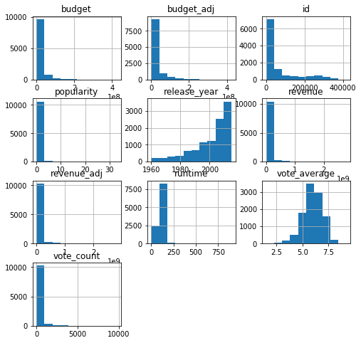

```python
#explore data visually
df_2.hist(figsize =(8,8));
```

and now after see histogram about data i'd like to know summary statics about numeric data and the way to do this is describe()

```python
# summary statics of numeric value
df_2.describe()
```

|  | id | popularity | budget | revenue | runtime | vote_count | vote_average | release_year | budget_adj | revenue_adj |
| --- | --- | --- | --- | --- | --- | --- | --- | --- | --- | --- |
| count | 10821.000000 | 10821.000000 | 1.082100e+04 | 1.082100e+04 | 10821.000000 | 10821.000000 | 10821.000000 | 10821.000000 | 1.082100e+04 | 1.082100e+04 |
| mean | 65722.143055 | 0.648530 | 2.235699e+07 | 6.206039e+07 | 102.130302 | 218.211810 | 5.971509 | 2001.294890 | 1.762011e+07 | 5.157685e+07 |
| std | 91841.687567 | 1.001704 | 2.805607e+07 | 1.112216e+08 | 30.872755 | 576.672383 | 0.933671 | 12.819687 | 3.435943e+07 | 1.448953e+08 |
| min | 5.000000 | 0.000188 | 1.000000e+00 | 2.000000e+00 | 0.000000 | 10.000000 | 1.500000 | 1960.000000 | 0.000000e+00 | 0.000000e+00 |
| 25% | 10578.000000 | 0.209036 | 1.468259e+07 | 3.998782e+07 | 90.000000 | 17.000000 | 5.400000 | 1995.000000 | 0.000000e+00 | 0.000000e+00 |
| 50% | 20533.000000 | 0.385121 | 1.468259e+07 | 3.998782e+07 | 99.000000 | 38.000000 | 6.000000 | 2006.000000 | 0.000000e+00 | 0.000000e+00 |
| 75% | 74998.000000 | 0.716336 | 1.500000e+07 | 3.998782e+07 | 111.000000 | 146.000000 | 6.600000 | 2011.000000 | 2.099042e+07 | 3.398486e+07 |
| max | 417859.000000 | 32.985763 | 4.250000e+08 | 2.781506e+09 | 900.000000 | 9767.000000 | 9.200000 | 2015.000000 | 4.250000e+08 | 2.827124e+09 |

### Research Question 1 (Is the highe rating movies has certain condition?)

and i just relized if i change the numeric value in vote average to adjective that would be easier for me to deal with data so i just did what they did in classroom by getting the desribe numbers in vote average value like this df_2['vote_averge'].decsribe()and take the min , 25% , 50%,75% and max and replace it whit words like amazing , good , bad or just fine then but this in nuw column.

```python
# first of all let's modified the data  by adding new column that has adjective reflet the number in vote_average
vote_edges =[1.500000,5.400000,6.000000,6.600000,9.200000]
```

```python
vote_names =['Amazing','good','fine','bad']
```

```python
df_2['rating_words'] = pd.cut(df_2['vote_average'], vote_edges, labels=vote_names)

# Checks for successful creation of this column
df_2.head()
```

|  | id | popularity | budget | revenue | original_title | director | runtime | vote_count | vote_average | release_year | budget_adj | revenue_adj | rating_words |
| --- | --- | --- | --- | --- | --- | --- | --- | --- | --- | --- | --- | --- | --- |
| 0 | 135397 | 32.985763 | 150000000.0 | 1.513529e+09 | Jurassic World | Colin Trevorrow | 124 | 5562 | 6.5 | 2015 | 137999939.3 | 1.392446e+09 | fine |
| 1 | 76341 | 28.419936 | 150000000.0 | 3.784364e+08 | Mad Max: Fury Road | George Miller | 120 | 6185 | 7.1 | 2015 | 137999939.3 | 3.481613e+08 | bad |
| 2 | 262500 | 13.112507 | 110000000.0 | 2.952382e+08 | Insurgent | Robert Schwentke | 119 | 2480 | 6.3 | 2015 | 101199955.5 | 2.716190e+08 | fine |
| 3 | 140607 | 11.173104 | 200000000.0 | 2.068178e+09 | Star Wars: The Force Awakens | J.J. Abrams | 136 | 5292 | 7.5 | 2015 | 183999919.0 | 1.902723e+09 | bad |
| 4 | 168259 | 9.335014 | 190000000.0 | 1.506249e+09 | Furious 7 | James Wan | 137 | 2947 | 7.3 | 2015 | 174799923.1 | 1.385749e+09 | bad |

and i just want to see the propotion of each vote rating in whole data so the better way to visual this by pie chart

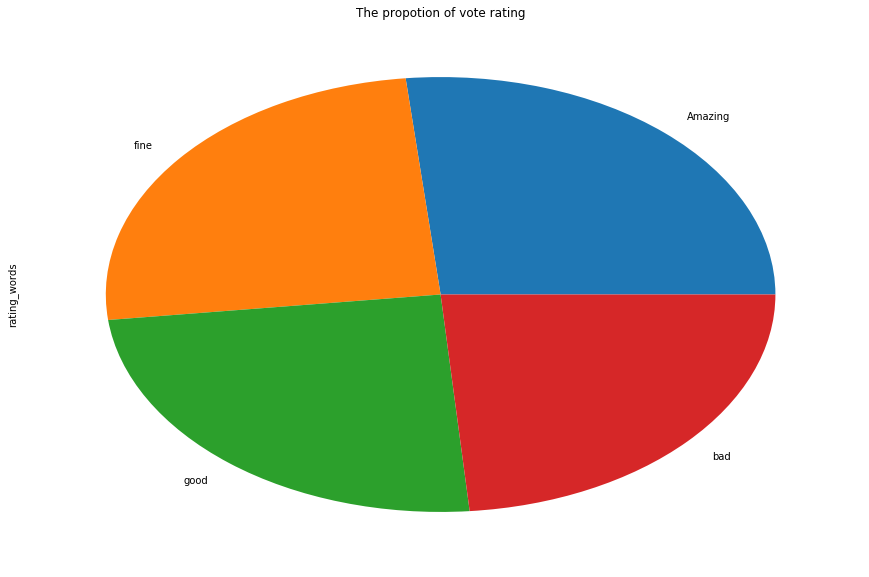

```python
#make visualazation to see the proption of vote rating in general
df_2['rating_words'].value_counts().plot(kind='pie',title='The propotion of vote rating',figsize=(15,10));
```

and now i want know if budget has something with high rating movie and better way for that is see that by bar chart to see the movie with high budget get high rating or not

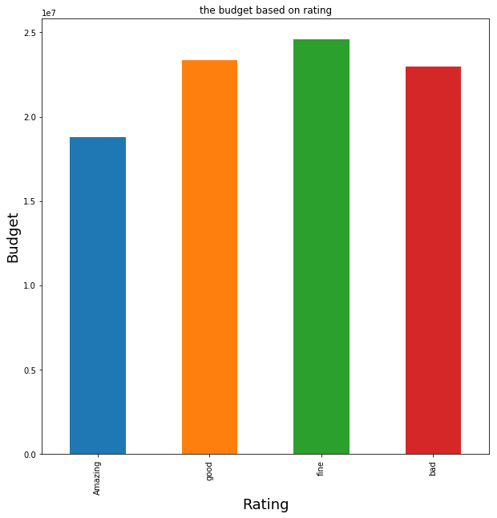

```python
# see the budget has something with high rating
df_2.groupby('rating_words')['budget'].mean().plot(kind='bar',title=('the budget based on rating'),figsize=(10,10));
plt.xlabel('Rating',fontsize=18);
plt.ylabel('Budget',fontsize=18);
```

and now i want know if revenue has something with high rating movie and better way for that is see that by bar chart to see the movie with high revenue get high rating or not

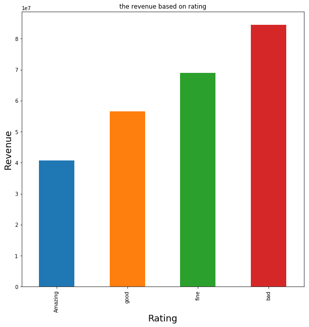

```python
#see the revenue has something with high rating
df_2.groupby('rating_words')['revenue'].mean().plot(kind='bar',title =('the revenue based on rating'),figsize=(10,10));
plt.xlabel('Rating',fontsize=18);
plt.ylabel('Revenue',fontsize=18);
```

and now i want know if popularity has something with high rating movie and better way for that is see that by bar chart to see the movie with high popularity get high rating or not

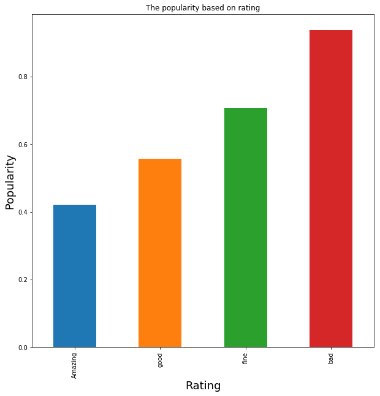

```python
df_2.groupby('rating_words')['popularity'].mean().plot(kind='bar',title=('The popularity based on rating'),figsize=(10,10));
plt.xlabel('Rating',fontsize=18);
plt.ylabel('Popularity',fontsize=18);
```

```python
#to make sure there is no realation between budget and high rating
df_a= df_2.query('rating_words =="Amazing"').mean().budget
```

```python
df_m= df_2.query('rating_words == "good"').mean().budget
```

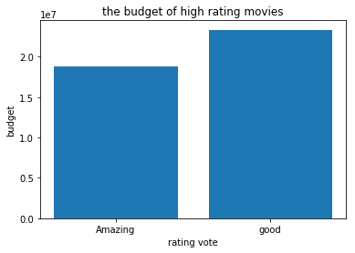

```python
locations = [1, 2]
heights = [df_a, df_m]
labels = ['Amazing', 'good']
plt.bar(locations, heights, tick_label=labels)
plt.title('the budget of high rating movies')
plt.xlabel('rating vote')
plt.ylabel('budget');
```

### Research Question 2 (How the revenve develobed over years ?and which year had the most movies?)

and here i want to see the developed of movies' revenue over years and the perfect way and better understanding for that is use line chart because it deals with years

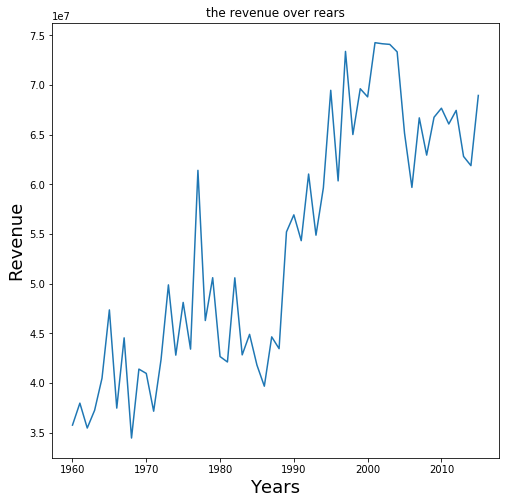

```python
#visulzation of movies revenue over years
df_2.groupby('release_year')['revenue'].mean().plot(kind='line',title=('the revenue over rears'),figsize=(8,8));
plt.xlabel('Years',fontsize=18);
plt.ylabel('Revenue',fontsize=18);
```

and here i want to see which years had highest movies production and what the movies numbers in that year, so firstly i get the number of movies in each year by value counts() and the better way to visual that by bar chart.

```python
#see which year had most production movies
df_2['release_year'].value_counts()
```

```
2014    695
2013    655
2015    626
2012    584
2011    539
2009    530
2008    489
2010    480
2007    435
2006    408
2005    364
2004    307
2003    281
2002    266
2001    242
```

[output cut: 42 more lines]

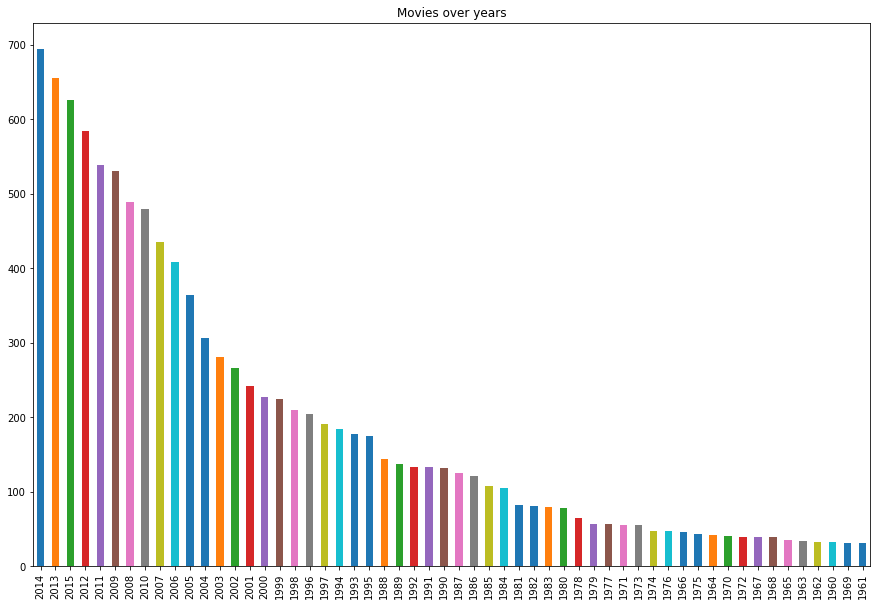

```python
#make visulzation
movies_per_year = df_2['release_year'].value_counts().plot(kind='bar',title = ('Movies over years'),figsize=[15,10])
```

and now i want to see the movie had most population so first i'm gonaa take the title and popularity and put this in new varible called movie popularity and better way to visual that is bar chart beacause it deals with the category and numeric values for each category so i use it .

### Research Question 3(What movies had the most population? and revenue?)

```python
#what movies had the most population
movie_popularity= df_2[['original_title', 'popularity']]
```

[output not shown]

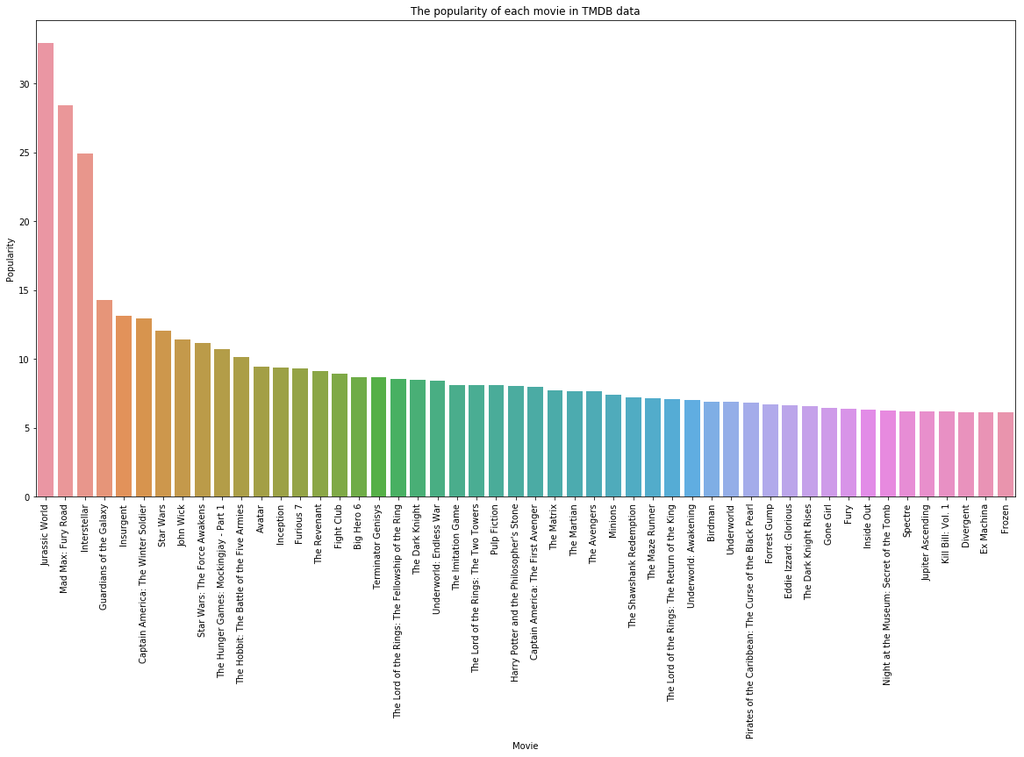

```python
# Plot the popularity of each movie in TMDB data
plt.figure(figsize=[20,10])
sns.barplot(data=movie_popularity.sort_values(by='popularity', ascending=False)[0:50], x='original_title', y='popularity')
plt.xticks(rotation=90)
plt.xlabel('Movie')
plt.ylabel('Popularity')
plt.title('The popularity of each movie in TMDB data');
```

and here i want to see the movie had most revenue so first i'm gonaa take the title and revenue and put this in new varible called movie revenue and better way to visual that is bar chart beacause it deals with the category and numeric values for each category so i use it .

```python
#what movies had the most revenue
movie_revenue = df_2[['original_title','revenue']]
```

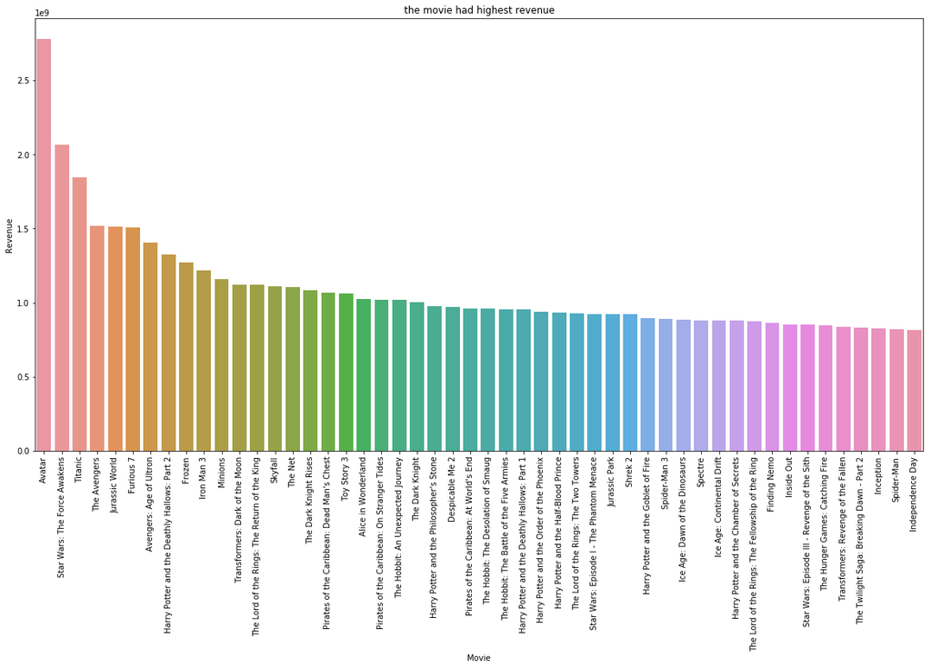

```python
#make visualzation
plt.figure(figsize=(20,10))
sns.barplot(data=movie_revenue.sort_values(by=('revenue'), ascending=False)[0:50], x=('original_title'), y=('revenue'))
plt.xticks(rotation=90)
plt.xlabel('Movie')
plt.ylabel('Revenue')
plt.title('the movie had highest revenue');
```

## limitation

the genre column didnot work with me because it has problem (|) and if i can handle it i could dig more in this data and explore the genre maybe it could has something with hihg rating .

> Before you submit your project, you need to create a .html or .pdf version of this notebook in the workspace here. To do that, run the code cell below. If it worked correctly, you should get a return code of 0, and you should see the generated .html file in the workspace directory (click on the orange Jupyter icon in the upper left).

> Alternatively, you can download this report as .html via the **File** > **Download as** submenu, and then manually upload it into the workspace directory by clicking on the orange Jupyter icon in the upper left, then using the Upload button.

> Once you've done this, you can submit your project by clicking on the "Submit Project" button in the lower right here. This will create and submit a zip file with this .ipynb doc and the .html or .pdf version you created. Congratulations!

```python
from subprocess import call
call(['python', '-m', 'nbconvert', 'Investigate_a_Dataset.ipynb'])
```

```
0
```